# **Bank Churn Prediction**

## **Objective**

Given a Bank customer, build a neural network-based classifier that can determine whether they will leave or not.

## **Context**

Businesses like banks which provide service have to worry about the problem of 'Churn' i.e. customers leaving and joining another service provider. It is important to understand which aspects of the service influence a customer's decision in this regard. Management can concentrate efforts on improvement of service, keeping in mind these priorities.

## **Imports**

```python
import warnings
warnings.filterwarnings('ignore')
```

```python
%matplotlib inline

import os
import tempfile

import numpy as np
import pandas as pd
import itertools as it

import matplotlib as mpl
import matplotlib.pyplot as plt
import seaborn as sns
from IPython.core.display import display, HTML

from sklearn.metrics import accuracy_score, confusion_matrix, recall_score, precision_score, f1_score, roc_auc_score
from sklearn.preprocessing import StandardScaler # Z-scores
from sklearn.model_selection import train_test_split

import tensorflow as tf
from tensorflow import keras
from tensorflow.keras import backend as K
from tensorflow.keras.models import Sequential
from tensorflow.keras.layers import Dense

# Increase cell width
display(HTML("<style>.container { width:98% !important; }</style>"))

# Update seaborn default style
sns.set_style("ticks")
sns.set_context("notebook")

my_random_state = 5
```

```python
mpl.rcParams['figure.figsize'] = (12, 10)
colors = plt.rcParams['axes.prop_cycle'].by_key()['color']
```

```python
print(tf.__version__)
```

```
2.3.1
```

## **Read Data**

```python
bank_churn_orig_df = pd.read_csv("bank.csv")
```

```python
print("")
print("Bank Churn Data")
print("***************")
print("")
display(HTML(bank_churn_orig_df.head(10).to_html()))
```

```
Bank Churn Data
***************
```

|  | RowNumber | CustomerId | Surname | CreditScore | Geography | Gender | Age | Tenure | Balance | NumOfProducts | HasCrCard | IsActiveMember | EstimatedSalary | Exited |
| --- | --- | --- | --- | --- | --- | --- | --- | --- | --- | --- | --- | --- | --- | --- |
| 0 | 1 | 15634602 | Hargrave | 619 | France | Female | 42 | 2 | 0.00 | 1 | 1 | 1 | 101348.88 | 1 |
| 1 | 2 | 15647311 | Hill | 608 | Spain | Female | 41 | 1 | 83807.86 | 1 | 0 | 1 | 112542.58 | 0 |
| 2 | 3 | 15619304 | Onio | 502 | France | Female | 42 | 8 | 159660.80 | 3 | 1 | 0 | 113931.57 | 1 |
| 3 | 4 | 15701354 | Boni | 699 | France | Female | 39 | 1 | 0.00 | 2 | 0 | 0 | 93826.63 | 0 |
| 4 | 5 | 15737888 | Mitchell | 850 | Spain | Female | 43 | 2 | 125510.82 | 1 | 1 | 1 | 79084.10 | 0 |
| 5 | 6 | 15574012 | Chu | 645 | Spain | Male | 44 | 8 | 113755.78 | 2 | 1 | 0 | 149756.71 | 1 |
| 6 | 7 | 15592531 | Bartlett | 822 | France | Male | 50 | 7 | 0.00 | 2 | 1 | 1 | 10062.80 | 0 |
| 7 | 8 | 15656148 | Obinna | 376 | Germany | Female | 29 | 4 | 115046.74 | 4 | 1 | 0 | 119346.88 | 1 |
| 8 | 9 | 15792365 | He | 501 | France | Male | 44 | 4 | 142051.07 | 2 | 0 | 1 | 74940.50 | 0 |
| 9 | 10 | 15592389 | H? | 684 | France | Male | 27 | 2 | 134603.88 | 1 | 1 | 1 | 71725.73 | 0 |

## **Datatypes and Description**

#### **Data Types**

```python
print("")
print("Bank Churn Data -- Info")
print(bank_churn_orig_df.info())
```

```
Bank Churn Data -- Info
<class 'pandas.core.frame.DataFrame'>
RangeIndex: 10000 entries, 0 to 9999
Data columns (total 14 columns):
 #   Column           Non-Null Count  Dtype
---  ------           --------------  -----
 0   RowNumber        10000 non-null  int64
 1   CustomerId       10000 non-null  int64
 2   Surname          10000 non-null  object
 3   CreditScore      10000 non-null  int64
 4   Geography        10000 non-null  object
 5   Gender           10000 non-null  object
 6   Age              10000 non-null  int64
 7   Tenure           10000 non-null  int64
 8   Balance          10000 non-null  float64
 9   NumOfProducts    10000 non-null  int64
 10  HasCrCard        10000 non-null  int64
 11  IsActiveMember   10000 non-null  int64
 12  EstimatedSalary  10000 non-null  float64
 13  Exited           10000 non-null  int64
dtypes: float64(2), int64(9), object(3)
memory usage: 1.1+ MB
None
```

##### **Observation**

- dataset has **10,000 entries**
- dataset has **14 features**
- We see a combination of integer, float and object type features
- There are no null values in terms of missing values or NaN for any of the columns

#### **Description**

Based on the problem statement, the description of the columns are

```
RowNumber       Row number for the entry
CustomerId      Unique customer ID
Surname         Surname of the customer
CreditScore     Credit Score of the customer
Geography       Geographical location of the customer
Gender          Gender of the customer
Age             Age of the customer
Tenure          Tenure of the customer with this bank
Balance         Customer balance with the bank
NumOfProducts   Number of products from the bank, that the customer uses
HasCrCard       Indicates whether the customer has a credit card
IsActiveMember  Indicates if the cutomer is an active member of the bank
EstimatedSalary Estimated salary of the customer
Exited          Indicates if the customer exited the bank
```

##### **Observation**

- Based on the description, the datatypes matches

#### **Shape**

```python
print("")
print("Bank Churn Data -- Shape")
print(bank_churn_orig_df.shape)
```

```
Bank Churn Data -- Shape
(10000, 14)
```

## **Summary of Data**

- We can remove those columns which are unique for all users like **RowNumber**, **CustomerId** and **Surname**
- Also **Exited** is the target column. So we have **10 features** and **1 Target** columns

```python
bank_churn_df = bank_churn_orig_df.copy()

# Since we are looking for customer churn, we neednt have to worry about RowNumber, CustomerId,  and Surname and remove them beforehand
bank_churn_df.drop(["RowNumber", "CustomerId", "Surname"], axis=1, inplace=True)
```

```python
print("")
print("Bank Churn Data -- Describe")
display(HTML(bank_churn_df.describe().T.to_html()))
```

```
Bank Churn Data -- Describe
```

|  | count | mean | std | min | 25% | 50% | 75% | max |
| --- | --- | --- | --- | --- | --- | --- | --- | --- |
| CreditScore | 10000.0 | 650.528800 | 96.653299 | 350.00 | 584.00 | 652.000 | 718.0000 | 850.00 |
| Age | 10000.0 | 38.921800 | 10.487806 | 18.00 | 32.00 | 37.000 | 44.0000 | 92.00 |
| Tenure | 10000.0 | 5.012800 | 2.892174 | 0.00 | 3.00 | 5.000 | 7.0000 | 10.00 |
| Balance | 10000.0 | 76485.889288 | 62397.405202 | 0.00 | 0.00 | 97198.540 | 127644.2400 | 250898.09 |
| NumOfProducts | 10000.0 | 1.530200 | 0.581654 | 1.00 | 1.00 | 1.000 | 2.0000 | 4.00 |
| HasCrCard | 10000.0 | 0.705500 | 0.455840 | 0.00 | 0.00 | 1.000 | 1.0000 | 1.00 |
| IsActiveMember | 10000.0 | 0.515100 | 0.499797 | 0.00 | 0.00 | 1.000 | 1.0000 | 1.00 |
| EstimatedSalary | 10000.0 | 100090.239881 | 57510.492818 | 11.58 | 51002.11 | 100193.915 | 149388.2475 | 199992.48 |
| Exited | 10000.0 | 0.203700 | 0.402769 | 0.00 | 0.00 | 0.000 | 0.0000 | 1.00 |

## **Univariate Analysis**

### **Numerical Columns**

```
********************************************************* Analysis of : CreditScore *********************************************************

Null Values?                        : False
Na Values?                          : False
Min                                 : 350
Max                                 : 850
Range                               : 500.00
--------------
Mean                                : 650.53
Median                              : 652.00
Std Dev                             : 96.65
Skew                                : -0.07 (negative skew)
--------------
Q1 (1st Quartile)                   : 584.0
Q3 (3rd Quartile)                   : 718.0
IQR                                 : 134.00
------- Outliers using IQR -------
Lower whisker                       : 383.00
Upper whisker                       : 919.00
Number of lower outliers            : 15
Number of upper outliers            : 0
% of the lower outliers, in dataset : 0.15%
% of the upper outliers, in dataset : 0.00%
```

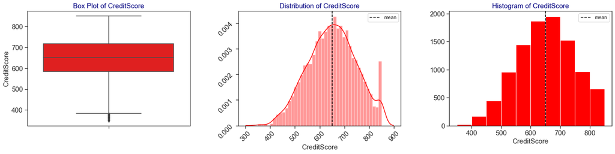

```
********************************************************* Analysis of : Age *********************************************************

Null Values?                        : False
Na Values?                          : False
Min                                 : 18
Max                                 : 92
Range                               : 74.00
--------------
Mean                                : 38.92
Median                              : 37.00
Std Dev                             : 10.49
Skew                                : 1.01 (positive skew)
--------------
Q1 (1st Quartile)                   : 32.0
Q3 (3rd Quartile)                   : 44.0
IQR                                 : 12.00
------- Outliers using IQR -------
Lower whisker                       : 14.00
Upper whisker                       : 62.00
Number of lower outliers            : 0
Number of upper outliers            : 359
% of the lower outliers, in dataset : 0.00%
% of the upper outliers, in dataset : 3.59%
```

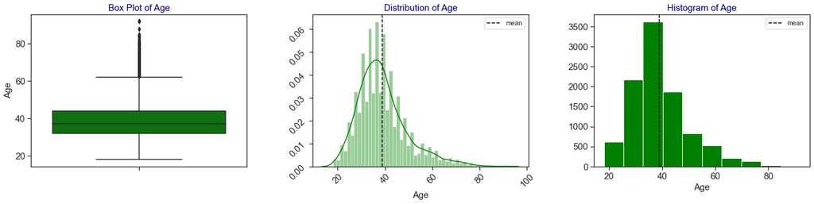

```
********************************************************* Analysis of : Balance *********************************************************

Null Values?                        : False
Na Values?                          : False
Min                                 : 0.0
Max                                 : 250898.09
Range                               : 250898.09
--------------
Mean                                : 76485.89
Median                              : 97198.54
Std Dev                             : 62397.41
Skew                                : -0.14 (negative skew)
--------------
Q1 (1st Quartile)                   : 0.0
Q3 (3rd Quartile)                   : 127644.24
IQR                                 : 127644.24
------- Outliers using IQR -------
Lower whisker                       : -191466.36
Upper whisker                       : 319110.60
Number of lower outliers            : 0
Number of upper outliers            : 0
% of the lower outliers, in dataset : 0.00%
% of the upper outliers, in dataset : 0.00%
```

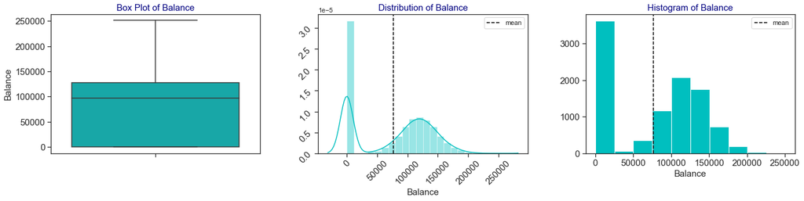

```
********************************************************* Analysis of : EstimatedSalary *********************************************************

Null Values?                        : False
Na Values?                          : False
Min                                 : 11.58
Max                                 : 199992.48
Range                               : 199980.90
--------------
Mean                                : 100090.24
Median                              : 100193.91
Std Dev                             : 57510.49
Skew                                : 0.00 (positive skew)
--------------
Q1 (1st Quartile)                   : 51002.11
Q3 (3rd Quartile)                   : 149388.2475
IQR                                 : 98386.14
------- Outliers using IQR -------
Lower whisker                       : -96577.10
Upper whisker                       : 296967.45
Number of lower outliers            : 0
Number of upper outliers            : 0
% of the lower outliers, in dataset : 0.00%
% of the upper outliers, in dataset : 0.00%
```

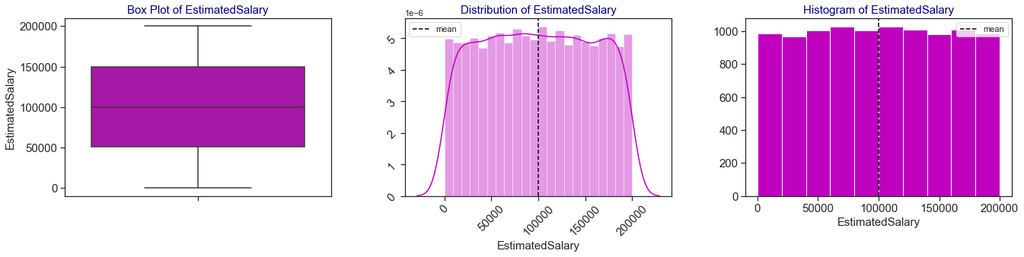

```python
numerical_columns = ["CreditScore", "Age", "Balance", "EstimatedSalary"]
cols_colors = ["r","g","c","m"]
cols_length = len(numerical_columns)

for column, index, color in it.zip_longest(numerical_columns, range(cols_length), cols_colors):
    print("")
    print("********************************************************* Analysis of : {0} *********************************************************".format(column))
    print("")
    minimum = bank_churn_df[column].min()
    maximum = bank_churn_df[column].max()
    min_max_range = maximum - minimum

    # Find the null/na values, min, max and range of the values
    print("Null Values?                        : {}".format(bank_churn_df[column].isnull().any()))
    print("Na Values?                          : {}".format(bank_churn_df[column].isna().any()))
    print("Min                                 : {}".format(minimum))
    print("Max                                 : {}".format(maximum))
    print("Range                               : {0:0.2f}".format(min_max_range))
    print("--------------")

    # Find the mean, median and std. dev
    print("Mean                                : {0:0.2f}".format(bank_churn_df[column].mean()))
    print("Median                              : {0:0.2f}".format(bank_churn_df[column].median()))
    print("Std Dev                             : {0:0.2f}".format(bank_churn_df[column].std()))
    col_skew = bank_churn_df[column].skew()

    # Find the skew
    col_skew_str = "positive skew" if col_skew > 0 else "negative skew"
    print("Skew                                : {0:0.2f} ({1})".format(col_skew, col_skew_str))
    print("--------------")
    q1 = bank_churn_df[column].quantile(q=0.25)
    q3 = bank_churn_df[column].quantile(q=0.75)
    iqr = q3 - q1

    # Find the outliers
    print("Q1 (1st Quartile)                   : {}".format(q1))
    print("Q3 (3rd Quartile)                   : {}".format(q3))
    print("IQR                                 : {0:0.2f}".format(iqr))
    print("------- Outliers using IQR -------")
    lower_whisker = q1 - 1.5 * (iqr)
    upper_whisker = q3 + 1.5 * (iqr)
    print("Lower whisker                       : {0:0.2f}".format(lower_whisker))
    print("Upper whisker                       : {0:0.2f}".format(upper_whisker))
    num_below_lower = bank_churn_df[bank_churn_df[column] < lower_whisker][column].count()
    num_above_upper = bank_churn_df[bank_churn_df[column] > upper_whisker][column].count()
    perc_below_lower = (num_below_lower / len(bank_churn_df)) * 100
    perc_above_upper = (num_above_upper / len(bank_churn_df)) * 100
    print("Number of lower outliers            : {}".format(num_below_lower))
    print("Number of upper outliers            : {}".format(num_above_upper))
    print("% of the lower outliers, in dataset : {0:0.2f}%".format(perc_below_lower))
    print("% of the upper outliers, in dataset : {0:0.2f}%".format(perc_above_upper))
    print("")


    fig, (ax1,ax2,ax3)=plt.subplots(1,3,figsize=(20,6), edgecolor='k')

    #boxplot
    sns.boxplot(x=column,data=bank_churn_df,orient='v',ax=ax1, color=color)
    ax1.set_ylabel(column, fontsize=15)
    ax1.set_title('Box Plot of {}'.format(column), fontsize=15, color="navy")
    ax1.tick_params(labelsize=15)

    #distplot
    sns.distplot(bank_churn_df[column],ax=ax2, color=color)
    ax2.axvline(bank_churn_df[column].mean(),linestyle="dashed",label="mean",color="k")
    ax2.legend(loc="best")
    ax2.set_xlabel(column, fontsize=15)
    ax2.set_title('Distribution of {}'.format(column), fontsize=15, color="navy")
    ax2.tick_params(labelsize=15, labelrotation=45)

    #histogram
    ax3.hist(bank_churn_df[column], color=color)
    ax3.axvline(bank_churn_df[column].mean(),linestyle="dashed",label="mean",color="k")
    ax3.legend(loc="best")
    ax3.set_xlabel(column, fontsize=15)
    ax3.set_title('Histogram of {}'.format(column), fontsize=15, color="navy")
    ax3.tick_params(labelsize=15)

    plt.tight_layout(pad=4.5)
    plt.show();

    print("")

    print("*************************************************************************************************************************************")
```

##### **Observation**

- **Null Values** - None of the parameters have null values
- **Missing Values** - None of the parameters have missing values
- **Outliers** - *Age*, *CreditScore* have outliers
- **CreditScore** - Has almost normal distribution, except for high creditscore. We see about 2 gaussians. We see a few outliers, which shows that some customers have very low creditscore.
- **Age** - We see 1-2 gaussians with positive skew. We see couple of outliers showing some customers do exist with age above 60
- **Balance** - We see 2 gaussians with negative skew. No outliers exists.
- **EstimatedSalary** - We see one gaussian with more or less equal distribution of salary for various bands. No outliers exist

### **Categorical Columns**

```python
categorical_columns = ["Geography", "Gender", "HasCrCard", "IsActiveMember", "Tenure", "NumOfProducts"]

print("Checking null, na and value count of category columns")
print("*****************************************************")
print("")
for column in categorical_columns:
    print("")
    print("********************************************************* Analysis of : {0} *********************************************************".format(column))
    print("")
    print("Null Values?                        : {}".format(bank_churn_df[column].isnull().any()))
    print("Na Values?                          : {}".format(bank_churn_df[column].isna().any()))
    print("Value Counts                        :")
    print("")
    print(bank_churn_df[column].value_counts())
    print("")
    print("*************************************************************************************************************************************")
```

```
Checking null, na and value count of category columns


********************************************************* Analysis of : Geography *********************************************************

Null Values?                        : False
Na Values?                          : False
Value Counts                        :

France     5014
Germany    2509
Spain      2477
Name: Geography, dtype: int64


********************************************************* Analysis of : Gender *********************************************************

Null Values?                        : False
Na Values?                          : False
Value Counts                        :

Male      5457
Female    4543
Name: Gender, dtype: int64


********************************************************* Analysis of : HasCrCard *********************************************************

Null Values?                        : False
Na Values?                          : False
Value Counts                        :

1    7055
0    2945
Name: HasCrCard, dtype: int64


********************************************************* Analysis of : IsActiveMember *********************************************************

Null Values?                        : False
```

[output cut: 24 more lines]

```
0      413
Name: Tenure, dtype: int64


********************************************************* Analysis of : NumOfProducts *********************************************************

Null Values?                        : False
Na Values?                          : False
Value Counts                        :

1    5084
2    4590
3     266
4      60
Name: NumOfProducts, dtype: int64
```

##### **Observation**

- **Null Values** - None of the parameters have null values
- **Missing Values** - None of the parameters have missing values

#### **Distribution**

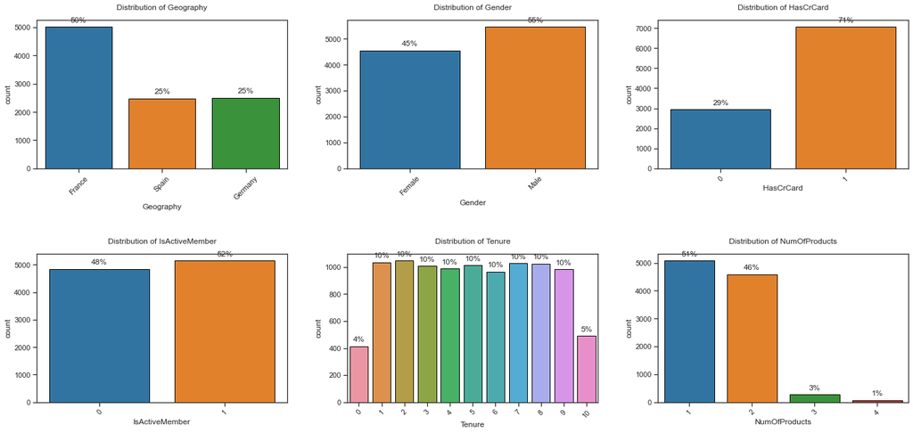

```python
num_plots = len(categorical_columns)
total_cols = 3
total_rows = 2
fig, axs = plt.subplots(nrows=total_rows, ncols=total_cols, figsize=(20, 10))
for i, var in enumerate(categorical_columns):
    row = i//total_cols
    pos = i % total_cols
    ax = sns.countplot(bank_churn_df[var], edgecolor="black", ax=axs[row][pos])
    total = len(bank_churn_df[var])
    for p in ax.patches:
        percentage = '{:.0f}%'.format(100 * p.get_height()/total)
        x = p.get_x() + 0.4
        y = p.get_y() + p.get_height()
        ax.annotate(percentage, (x,y), size = 12, ha = 'center', va = 'center', xytext = (0, 10), textcoords = 'offset points')
    ax.set_title("Distribution of {0}".format(var), pad=15)
    ax.set_xticklabels(ax.get_xticklabels(), rotation=45)
fig.tight_layout(pad=3.5)
plt.show();
```

##### **Observation**

- **Geography** - Majority of customers(50%) are from France, and the remaining equally distributed from Spain and Germany
- **Gender** - Majority of customers(55%) are *Male*. *Female* customers are close second at *45%*
- **HasCrCard** - Majority of customers(71%) have a credit card.
- **IsActiveMember** - 52% of customers are active, wheareas 48% are not
- **Tenure** - Tenure of the customers are equally distributed between 1-9 years. Whereas 4% of customers have no tenure and 5% of customer have tenure of 10 years.
- **NumOfProducts** - Majority of customers(51%) use only 1 product from the bank and closely 46% of customers use 2 products from the bank.

#### **Distribution with Target**

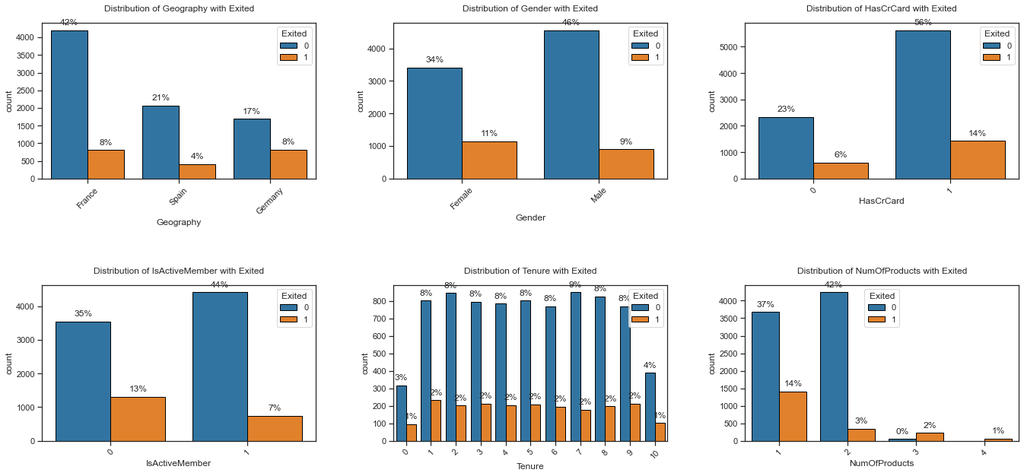

```python
fig, axs = plt.subplots(nrows=total_rows, ncols=total_cols, figsize=(20, 10))
for i, var in enumerate(categorical_columns):
    row = i//total_cols
    pos = i % total_cols
    ax = sns.countplot(x=var, hue="Exited", data=bank_churn_df, edgecolor="black", ax=axs[row][pos])
    total = len(bank_churn_df[var])
    for p in ax.patches:
        percentage = '{:.0f}%'.format(100 * p.get_height()/total)
        x = p.get_x() + 0.2
        y = p.get_y() + p.get_height()
        ax.annotate(percentage, (x,y), size = 12, ha = 'center', va = 'center', xytext = (0, 10), textcoords = 'offset points')
    ax.set_title("Distribution of {0} with Exited".format(var), pad=15)
    ax.set_xticklabels(ax.get_xticklabels(), rotation=45)
# axs[1,2].set_axis_off()
fig.tight_layout(pad=4.5)
plt.show();
```

##### **Observation**

- **Georgraphy** - Customers who exited, are equally distributed in France and Germany at 8%. Spain comes seconds at 4%
- **Gender** - Though the distribution shows there are more Male customers as compared to Female customers, of those who exited, we see the majority are Female at 11%
- **HasCrCard** - 14% of customers with credit card, exited. This could be a contributing factor.
- **IsActiveMember** - Only 7% of active customers exited, whereas 13% of inactive customers exited. This could be a contributing factor.
- **Tenure** - Between 1-9 years, 2% of customers exited and this is equally distributed. Whereas only 1% of customers with tenure of 10 exited.
- **NumOfProducts** - 14% of customers using 1 product exited, whereas customers with 2 products exited only 3%. This could also mean, customers using more products have a tie in with the bank and quit less frequently

### **Target Column Distribution**

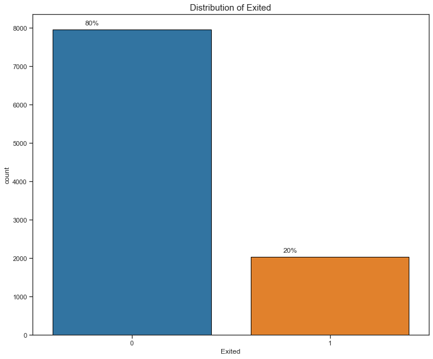

```python
ax = sns.countplot(x="Exited", data=bank_churn_df, edgecolor="black")
total = len(bank_churn_df["Exited"])
for p in ax.patches:
    percentage = '{:.0f}%'.format(100 * p.get_height()/total)
    x = p.get_x() + 0.2
    y = p.get_y() + p.get_height()
    ax.annotate(percentage, (x,y), size = 12, ha = 'center', va = 'center', xytext = (0, 10), textcoords = 'offset points')
plt.title('Distribution of Exited', fontsize=15)
plt.show();
```

##### **Observation**

- The data is highly **imbalanced**. Only 20% of dataset is for customers who exited. This might cause problems with prediction as the model might not have enough information to learn the pattern.

## **Bivariate Analysis**

### **Pair Plot**

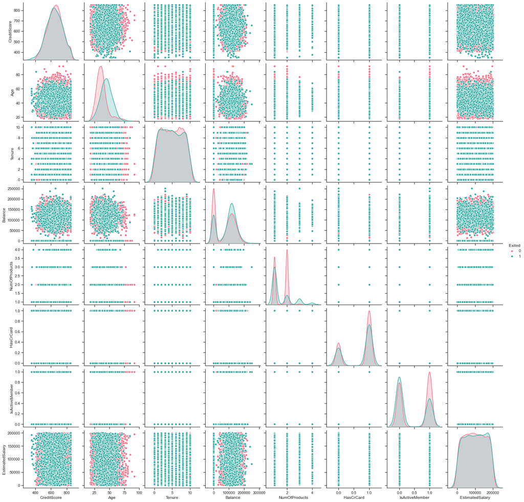

```python
sns.pairplot(bank_churn_df,diag_kind='kde', hue="Exited", palette="husl")
plt.show();
```

##### Observation

- We dont see much correlation information from the plots.
- **CreditScore**
  - Customers who exited, are mostly in the age range 30-60 and have a credit score in all the ranges.
- **Age**
  - Customers using 4 products from the bank belong to 30-60 age range
- **Balance**
  - Customers using 4 products have balance in the range 100000-200000
- **NumOfProducts**
  - Customers who exited, have used 3 or 4 products.
  - Customers who use 2 products dont exit as much
- **IsActiveMember**
  - Customers who are not active and use 2-4 products have exited

### **Correlation Matrix**

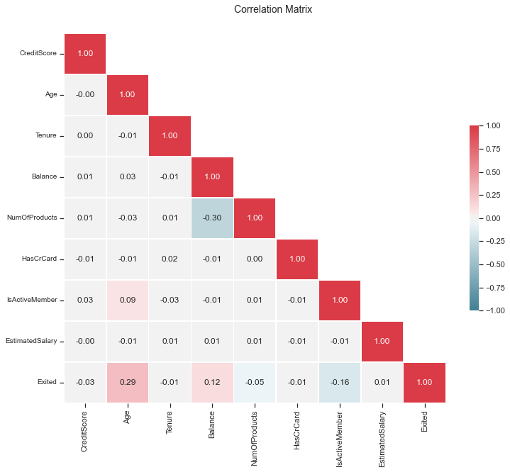

```python
# Graphical representation of the correlation
correlation = bank_churn_df.corr()

# Generate a custom diverging colormap
cmap = sns.diverging_palette(220, 10, as_cmap=True)

fig_corr, axes_corr = plt.subplots(nrows=1, ncols=1, figsize=(12,10))

# Hide the upper half of the matrix - So that we see the values only once
mask = np.zeros_like(correlation)
mask[np.triu_indices_from(mask, 1)] = True
sns.heatmap(correlation, ax=axes_corr,  linewidths=.5, cbar_kws={"shrink": .5}, cmap=cmap, vmin=-1, annot=True, fmt=".2f", mask=mask)
fig_corr.suptitle("Correlation Matrix", fontsize=14)
plt.yticks(fontsize=10, va="center")
fig_corr.tight_layout(pad=4.5)
plt.show();
```

##### Observation

- We dont observe any high correlation on either direction among the columns (for removal) or with the target column (Exited).
- **Balance** has a small negative correlation with **NumOfProducts**, but doesnt seem high enough to be significant.
- **Age** seems to have a small postive correlation with Exited. But not very significant

## **Other Analysis**

### **CreditScore vs Balance on Exited**

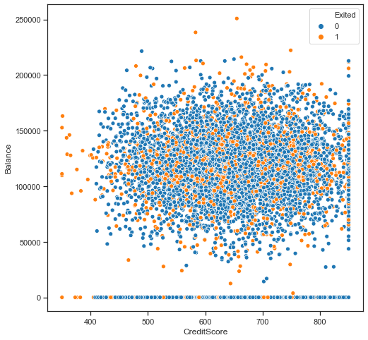

```python
plt.figure(figsize = (8,8))
sns.scatterplot(x="CreditScore", y="Balance", hue="Exited", data=bank_churn_df)
plt.show();
```

##### Observation

- We see a lot of customers with 0 balance and with varying credit score. A small percentage of them actually quit.

### **Age vs Estimated Salary on Exited**

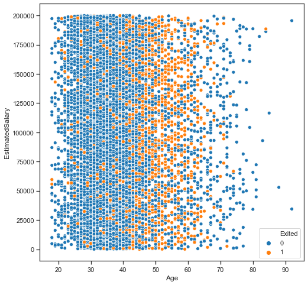

```python
plt.figure(figsize = (8,8))
sns.scatterplot(x="Age", y="EstimatedSalary", hue="Exited", data=bank_churn_df)
plt.show();
```

##### **Observation**

- Estimated Salary doesnt play a part in this observation
- Mostly customers in the age range 43-63 have exited, regardless of their salary

### **Georgraphy vs Balance On Exited**

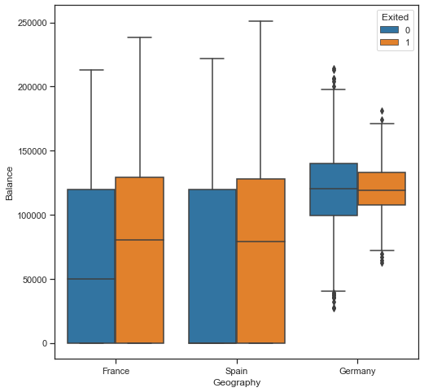

```python
plt.figure(figsize = (8,8))
sns.boxplot(x="Geography", y="Balance", hue="Exited", data=bank_churn_df)
plt.show();
```

##### **Observation**

- France and Spain seem to have an equal distribution of Balance, for both exited and non-exited customers
- Germany has a higher median balance for both the cases

### **Gender vs EstimatedSalary On Exited**

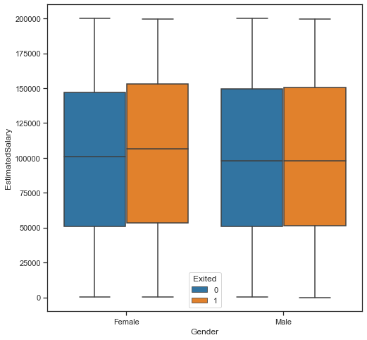

```python
plt.figure(figsize = (8,8))
sns.boxplot(x="Gender", y="EstimatedSalary", hue="Exited", data=bank_churn_df)
plt.show();
```

##### **Observation**

- Both Male and Female non-exited customers have similar range of EstimatedSalary
- Female exited customers have higher median EstimatedSalary rather their Male counterpart

### **NumOfProducts vs Balance On Exited**

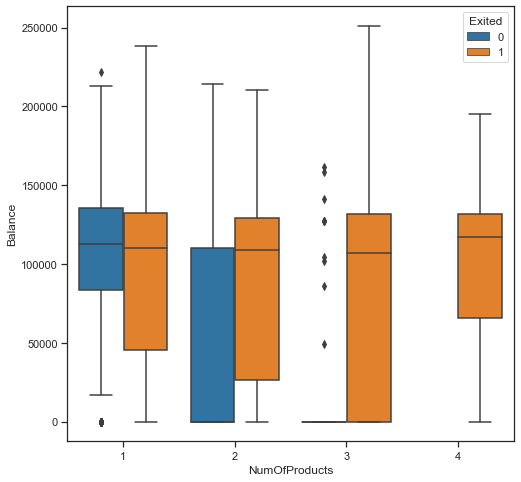

```python
plt.figure(figsize = (8,8))
sns.boxplot(x="NumOfProducts", y="Balance", hue="Exited", data=bank_churn_df)
plt.show();
```

##### **Observation**

- Customer with all NumOfProducts and who exited have more or less same median Balance

## **Encoding of Data**

Since *Gender* and *Geography* are categorical, we convert them to columns using one-hot encoding

```python
oneHotColumns = ["Gender", "Geography"]
bank_churn_df = pd.get_dummies(bank_churn_df, columns=oneHotColumns)
```

```python
bank_churn_df.head()
```

|  | CreditScore | Age | Tenure | Balance | NumOfProducts | HasCrCard | IsActiveMember | EstimatedSalary | Exited | Gender_Female | Gender_Male | Geography_France | Geography_Germany | Geography_Spain |
| --- | --- | --- | --- | --- | --- | --- | --- | --- | --- | --- | --- | --- | --- | --- |
| 0 | 619 | 42 | 2 | 0.00 | 1 | 1 | 1 | 101348.88 | 1 | 1 | 0 | 1 | 0 | 0 |
| 1 | 608 | 41 | 1 | 83807.86 | 1 | 0 | 1 | 112542.58 | 0 | 1 | 0 | 0 | 0 | 1 |
| 2 | 502 | 42 | 8 | 159660.80 | 3 | 1 | 0 | 113931.57 | 1 | 1 | 0 | 1 | 0 | 0 |
| 3 | 699 | 39 | 1 | 0.00 | 2 | 0 | 0 | 93826.63 | 0 | 1 | 0 | 1 | 0 | 0 |
| 4 | 850 | 43 | 2 | 125510.82 | 1 | 1 | 1 | 79084.10 | 0 | 1 | 0 | 0 | 0 | 1 |

## **Splitting Data and Normalization**

### Splitting Training, Validation and Testing datasets

```python
# Split into training, validation and testing datasets
train_df, test_df = train_test_split(bank_churn_df, test_size=0.2)
train_df, val_df = train_test_split(train_df, test_size=0.2)
```

```python
neg, pos = np.bincount(train_df['Exited'])
total = neg + pos
print('Examples:\n    Total: {}\n    Positive: {} ({:.2f}% of total)\n'.format(
    total, pos, 100 * pos / total))
```

```
Examples:
    Total: 6400
    Positive: 1305 (20.39% of total)
```

```python
# Form array of labels and features
train_labels = np.array(train_df.pop('Exited'))
bool_train_labels = train_labels != 0
val_labels = np.array(val_df.pop('Exited'))
test_labels = np.array(test_df.pop('Exited'))
```

```python
train_features = np.array(train_df)
val_features = np.array(val_df)
test_features = np.array(test_df)
```

### Normalize the values

```python
scaler = StandardScaler()
train_features = scaler.fit_transform(train_features)

val_features = scaler.transform(val_features)
test_features = scaler.transform(test_features)
```

```python
print('Training labels shape:', train_labels.shape)
print('Validation labels shape:', val_labels.shape)
print('Test labels shape:', test_labels.shape)

print('Training features shape:', train_features.shape)
print('Validation features shape:', val_features.shape)
print('Test features shape:', test_features.shape)
```

```
Training labels shape: (6400,)
Validation labels shape: (1600,)
Test labels shape: (2000,)
Training features shape: (6400, 13)
Validation features shape: (1600, 13)
Test features shape: (2000, 13)
```

### Check normalized values

Check some of the columns for both the negative and positive cases, to observe the distribution

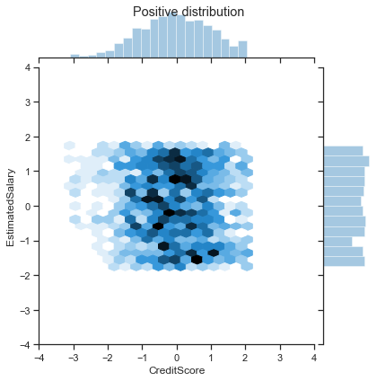

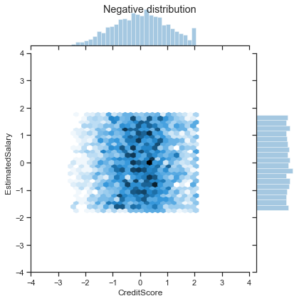

```python
pos_df = pd.DataFrame(train_features[ bool_train_labels], columns = train_df.columns)
neg_df = pd.DataFrame(train_features[~bool_train_labels], columns = train_df.columns)

sns.jointplot(pos_df['CreditScore'], pos_df['EstimatedSalary'],kind='hex', xlim = (-4,4), ylim = (-4,4))
plt.suptitle("Positive distribution")

sns.jointplot(neg_df['CreditScore'], neg_df['EstimatedSalary'],kind='hex', xlim = (-4,4), ylim = (-4,4))
_ = plt.suptitle("Negative distribution")
```

##### **Observation**

- The distribution looks correct. We have normalized the values and they are in the *+/- 2* range
- The positive distribution shows much higher rate of extreme values

## **ANN**

### **Important Metric**

```python
METRICS = [
    keras.metrics.BinaryAccuracy(name="accuracy"),
]

# Dataframe to hold the output from each model
result_column_names = ["Model", "Loss", "Accuracy", "Precision", "Recall", "F1", "AUC"]
model_comp_df = pd.DataFrame(columns = result_column_names)
```

### Baseline Model

```python
EPOCHS = 500
BATCH_SIZE = 2048
THRESHOLD = 0.5
```

- We make a baseline model with 1 hidden layer of 64 neurons, with *relu* activation
- We use a sigmoid function as the outer layer to get the probability

```python
model = Sequential()

model.add(Dense(64, input_shape = (train_features.shape[-1],), activation = 'relu'))
model.add(Dense(1, activation = 'sigmoid'))

opt = keras.optimizers.Adam(lr = 0.001)
model.compile(optimizer = opt, loss = 'binary_crossentropy', metrics=METRICS)
```

```python
model.summary()
```

```
Model: "sequential"
_________________________________________________________________
Layer (type)                 Output Shape              Param #
=================================================================
dense (Dense)                (None, 64)                896
_________________________________________________________________
dense_1 (Dense)              (None, 1)                 65
=================================================================
Total params: 961
Trainable params: 961
Non-trainable params: 0
_________________________________________________________________
```

```python
baseline_history = model.fit(
    train_features,
    train_labels,
    batch_size=BATCH_SIZE,
    epochs=EPOCHS,
    validation_data=(val_features, val_labels),
    verbose = False)
```

#### Baseline Metrics

```python
def calculate_metrics(actual, predicted):
    accuracy = accuracy_score(actual, predicted)
    precision = precision_score(actual, predicted)
    recall = recall_score(actual, predicted)
    f1 = f1_score(actual, predicted)
    auc = roc_auc_score(actual, predicted)
    return (accuracy, precision, recall, f1, auc)
```

```python
def plot_loss(history):
    metrics =  ['loss']
    for n, metric in enumerate(metrics):
        fig_conf, axs = plt.subplots(nrows=1, ncols=3, figsize=(20,5))
        name = metric.replace("_"," ").capitalize()
        axs[1].plot(history.epoch,  history.history[metric], color=colors[0], label='Train')
        axs[1].plot(history.epoch, history.history['val_'+metric], color=colors[0], linestyle="--", label='Val')
        axs[1].set_xlabel('Epoch')
        axs[1].set_ylabel(name)
        axs[1].legend()
        axs[0].set_axis_off()
        axs[2].set_axis_off()
        fig_conf.tight_layout(pad=3.5)
        plt.show();
```

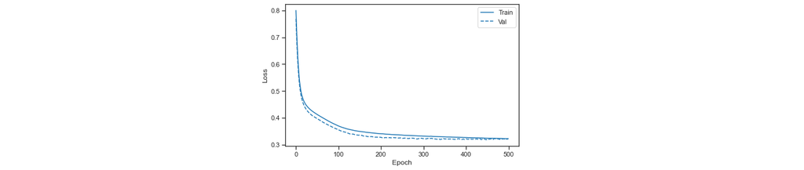

```python
plot_loss(baseline_history)
```

##### Observation

- We see that it takes a while for the loss to stabilize. Even with 500 epochs, we see that it never goes to a very low value.
- Validation seems to be more stable, doing a little better than training, when converging
- We should look for opportunities to improve on this

#### Baseline Predictions

```python
train_predictions_baseline = np.where(model.predict(train_features, batch_size=BATCH_SIZE) > THRESHOLD, 1, 0)
test_predictions_baseline = np.where(model.predict(test_features, batch_size=BATCH_SIZE) > THRESHOLD, 1, 0)
baseline_results = model.evaluate(test_features, test_labels, batch_size=BATCH_SIZE, verbose=0)
baseline_metrics = calculate_metrics(test_labels, test_predictions_baseline)
```

```python
def create_confusion_matrix(axs, row, pos, description, actual, predicted, loss, accuracy, precision, recall, f1, auc):
    if axs.ndim > 1:
        axis_heat_map = axs[row][pos]
    else:
        axis_heat_map = axs[pos]

    labels = ["TN","FP","FN","TP"]
    cf = confusion_matrix( actual, predicted)
    group_labels = ["{}\n\n".format(value) for value in labels]
    group_counts = ["{0:0.0f}\n\n".format(value) for value in cf.flatten()]
    group_percentages = ["{0:.2%}".format(value) for value in cf.flatten()/np.sum(cf)]
    box_labels = [f"{v1}{v2}{v3}".strip() for v1, v2, v3 in zip(group_labels,group_counts,group_percentages)]
    box_labels = np.asarray(box_labels).reshape(cf.shape[0],cf.shape[1])

    stats_text = "\n\nLoss = {:0.3f}\nAccuracy = {:0.3f}\nPrecision = {:0.3f}\nRecall = {:0.3f}\nF1 = {:0.3f}\nAUC = {:0.3f}\n".format(loss, accuracy, precision, recall, f1, auc)

    heatmap = sns.heatmap(cf, annot=box_labels, annot_kws={"size": 14}, linewidths=0.5, linecolor='w', fmt="", cmap="Oranges", cbar=False, xticklabels="auto", yticklabels="auto", ax=axis_heat_map, square=True)
    axis_heat_map.set_title(description, fontsize=14)
    axis_heat_map.set_ylabel("Actual", fontsize=14)
    axis_heat_map.set_xlabel("Predicted" + stats_text, fontsize=14)
    axis_heat_map.set_xticklabels(axis_heat_map.get_xticklabels(), rotation = 45, fontsize = 10)
    axis_heat_map.set_yticklabels(axis_heat_map.get_yticklabels(), rotation = 25, fontsize = 10)

    return_list = [value for value in cf.flatten()]
    return return_list
```

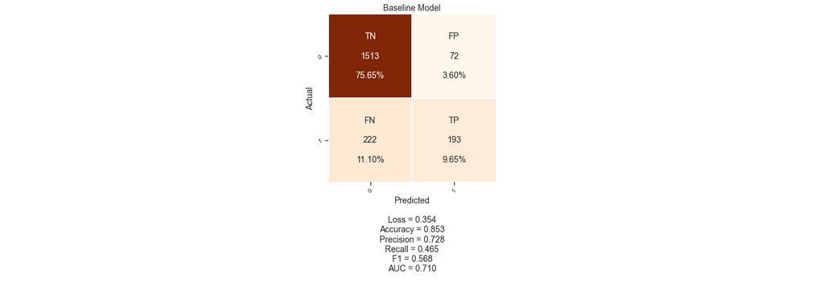

```python
fig_conf, axs = plt.subplots(nrows=1, ncols=3, figsize=(20,7))
create_confusion_matrix(axs, 0, 1, "Baseline Model", test_labels, test_predictions_baseline, baseline_results[0], baseline_metrics[0], baseline_metrics[1], baseline_metrics[2], baseline_metrics[3], baseline_metrics[4])
axs[0].set_axis_off()
axs[2].set_axis_off()
fig_conf.tight_layout(pad=3.5)
plt.show();
```

##### Observation

- The Accuracy and Precision are good with the baseline
- Recall is pretty low and we should aim to improve on this , as this is our important metric

```python
model_comp_df.loc[0] = ["Baseline", baseline_results[0], baseline_metrics[0], baseline_metrics[1], baseline_metrics[2], baseline_metrics[3], baseline_metrics[4]]
```

### Improvement 1 - Adding class weights

Since we dont have that many postive datasets (class imbalance), we might want to have the classifier heavily weight the few positive datasets that are there.

```python
weight_for_0 = (1 / neg)*(total)/2.0
weight_for_1 = (1 / pos)*(total)/2.0

class_weight = {0: weight_for_0, 1: weight_for_1}

print('Weight for class 0: {:.2f}'.format(weight_for_0))
print('Weight for class 1: {:.2f}'.format(weight_for_1))
```

```
Weight for class 0: 0.63
Weight for class 1: 2.45
```

```python
weighted_model = Sequential()

weighted_model.add(Dense(64, input_shape = (train_features.shape[-1],), activation = 'relu'))
weighted_model.add(Dense(1, activation = 'sigmoid'))

opt = keras.optimizers.Adam(lr = 0.001)
weighted_model.compile(optimizer = opt, loss = 'binary_crossentropy', metrics=METRICS)
```

```python
weighted_history = weighted_model.fit(
    train_features,
    train_labels,
    batch_size=BATCH_SIZE,
    epochs=EPOCHS,
    validation_data=(val_features, val_labels),
    verbose = False,
    # The class weights go here
    class_weight=class_weight)
```

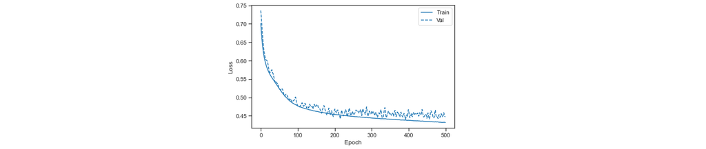

```python
plot_loss(weighted_history)
```

#### Improvement 1 - Predictions

```python
train_predictions_weighted = np.where(weighted_model.predict(train_features, batch_size=BATCH_SIZE) > THRESHOLD, 1, 0)
test_predictions_weighted = np.where(weighted_model.predict(test_features, batch_size=BATCH_SIZE) > THRESHOLD, 1, 0)
weighted_results = weighted_model.evaluate(test_features, test_labels,batch_size=BATCH_SIZE, verbose=0)
weighted_metrics = calculate_metrics(test_labels, test_predictions_weighted)
```

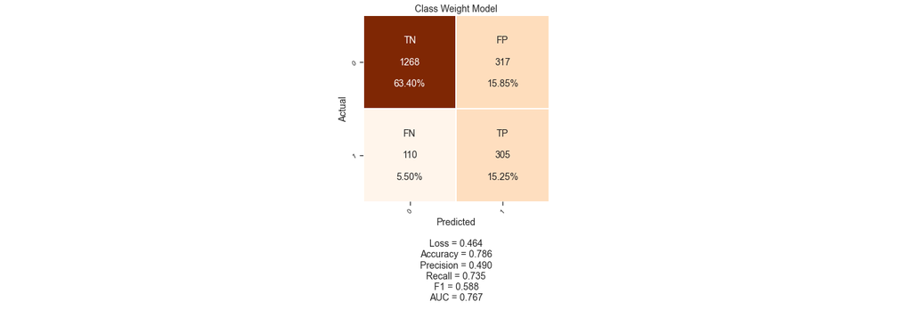

```python
fig_conf, axs = plt.subplots(nrows=1, ncols=3, figsize=(20,7))
create_confusion_matrix(axs, 0, 1, "Class Weight Model", test_labels, test_predictions_weighted, weighted_results[0], weighted_metrics[0], weighted_metrics[1], weighted_metrics[2], weighted_metrics[3], weighted_metrics[4])
axs[0].set_axis_off()
axs[2].set_axis_off()
fig_conf.tight_layout(pad=3.5)
plt.show();
```

##### Observation

- **Accuracy** and **Precision** are lower than the baseline. This is because of increased **FP**.
- **Recall** has improved significantly, as the model has found more **TP**
- Even with lower accuracy, the model has higher Recall. So it has been able to identify more customers who would exit the bank. This will be helpful for the bank to run some targetted campaigns for those customers.
- But with increased FP, the bank might also target higher number of customers who dont intend to exit. This might annoy the customers. So the bank would have to weigh in those factors as well.

```python
model_comp_df.loc[1] = ["Class Weight", weighted_results[0], weighted_metrics[0], weighted_metrics[1], weighted_metrics[2], weighted_metrics[3], weighted_metrics[4]]
```

### Improvement 2 - Oversampling the minority class

This is a related approach, wherein, to handle the class imbalance, we will oversample the minority class.

```python
# Collect list of positive and negative features and labels
pos_features = train_features[bool_train_labels]
neg_features = train_features[~bool_train_labels]

pos_labels = train_labels[bool_train_labels]
neg_labels = train_labels[~bool_train_labels]
```

```python
# Randomly choose ids from the positive features (replicate), as much as the number of negative features
ids = np.arange(len(pos_features))
choices = np.random.choice(ids, len(neg_features))

# For the randmom replicated id, get the features and label (set of rows which are duplicates from existing rows)
res_pos_features = pos_features[choices]
res_pos_labels = pos_labels[choices]

res_pos_features.shape
```

```
(5095, 13)
```

```python
# Concatenate the replicated rows with negative features and labels
resampled_features = np.concatenate([res_pos_features, neg_features], axis=0)
resampled_labels = np.concatenate([res_pos_labels, neg_labels], axis=0)

order = np.arange(len(resampled_labels))
np.random.shuffle(order)
resampled_features = resampled_features[order]
resampled_labels = resampled_labels[order]

resampled_features.shape
```

```
(10190, 13)
```

```python
resampled_model = Sequential()

resampled_model.add(Dense(64, input_shape = (train_features.shape[-1],), activation = 'relu'))
resampled_model.add(Dense(1, activation = 'sigmoid'))

opt = keras.optimizers.Adam(lr = 0.001)
resampled_model.compile(optimizer = opt, loss = 'binary_crossentropy', metrics=METRICS)
```

```python
resampled_history = resampled_model.fit(
    resampled_features,
    resampled_labels,
    batch_size=BATCH_SIZE,
    epochs=EPOCHS,
    validation_data=(val_features, val_labels),
    verbose = False)
```

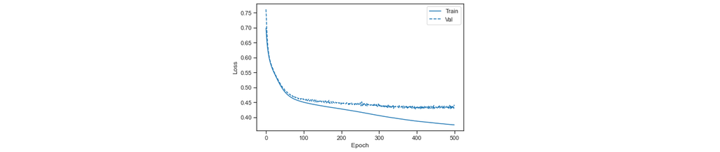

```python
plot_loss(resampled_history)
```

```python
train_predictions_resampled = np.where(resampled_model.predict(train_features, batch_size=BATCH_SIZE) > THRESHOLD, 1, 0)
test_predictions_resampled = np.where(resampled_model.predict(test_features, batch_size=BATCH_SIZE) > THRESHOLD, 1, 0)
resampled_results = resampled_model.evaluate(test_features, test_labels, batch_size=BATCH_SIZE, verbose=0)
resampled_metrics = calculate_metrics(test_labels, test_predictions_resampled)
```

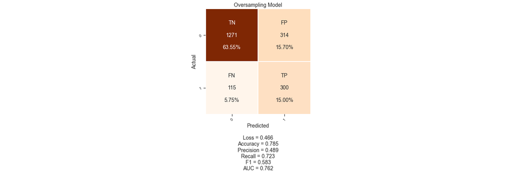

```python
fig_conf, axs = plt.subplots(nrows=1, ncols=3, figsize=(20,7))
create_confusion_matrix(axs, 0, 1, "Oversampling Model", test_labels, test_predictions_resampled, resampled_results[0], resampled_metrics[0], resampled_metrics[1], resampled_metrics[2], resampled_metrics[3], resampled_metrics[4])
axs[0].set_axis_off()
axs[2].set_axis_off()
fig_conf.tight_layout(pad=3.5)
plt.show();
```

##### Observation

- **Accuracy** and **Precision** are lower than the baseline. This is because of increase in **FP**
- **Recall** has improved significantly, as the model has found more **TP** as compared to the base model

```python
model_comp_df.loc[2] = ["Oversampled", resampled_results[0], resampled_metrics[0], resampled_metrics[1], resampled_metrics[2], resampled_metrics[3], resampled_metrics[4]]
```

### Improvement 3 - With class weights and more layers

In this model, we will use the class weights created earlier and add another extra hidden layer to the network

```python
weighted_2layer_model = Sequential()

weighted_2layer_model.add(Dense(64, input_shape = (train_features.shape[-1],), activation = 'relu'))
weighted_2layer_model.add(Dense(32, activation = 'tanh'))
weighted_2layer_model.add(Dense(1, activation = 'sigmoid'))

opt = keras.optimizers.Adam(lr = 0.001)
weighted_2layer_model.compile(optimizer = opt, loss = 'binary_crossentropy', metrics=METRICS)
```

```python
weighted_2layer_history = weighted_2layer_model.fit(
    train_features,
    train_labels,
    batch_size=BATCH_SIZE,
    epochs=EPOCHS,
    validation_data=(val_features, val_labels),
    verbose = False,
    # The class weights go here
    class_weight=class_weight)
```

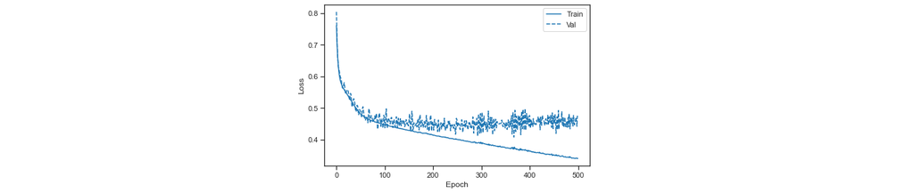

```python
plot_loss(weighted_2layer_history)
```

#### Improvement 3 - Predictions

```python
train_predictions_weighted_2layer = np.where(weighted_2layer_model.predict(train_features, batch_size=BATCH_SIZE) > THRESHOLD, 1, 0)
test_predictions_weighted_2layer = np.where(weighted_2layer_model.predict(test_features, batch_size=BATCH_SIZE) > THRESHOLD, 1, 0)
weighted_2layer_results = weighted_2layer_model.evaluate(test_features, test_labels,batch_size=BATCH_SIZE, verbose=0)
weighted_2layer_metrics = calculate_metrics(test_labels, test_predictions_weighted_2layer)
```

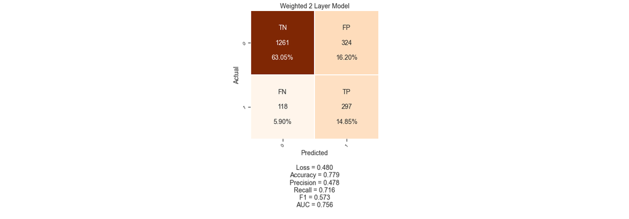

```python
fig_conf, axs = plt.subplots(nrows=1, ncols=3, figsize=(20,7))
create_confusion_matrix(axs, 0, 1, "Weighted 2 Layer Model", test_labels, test_predictions_weighted_2layer, weighted_2layer_results[0], weighted_2layer_metrics[0], weighted_2layer_metrics[1], weighted_2layer_metrics[2], weighted_2layer_metrics[3], weighted_2layer_metrics[4])
axs[0].set_axis_off()
axs[2].set_axis_off()
fig_conf.tight_layout(pad=3.5)
plt.show();
```

##### Observation

- There is no significant improvement as compared to single layer weighted model
- Recall is still better than baseline.

```python
model_comp_df.loc[3] = ["Class Weight - 2 Layers", weighted_2layer_results[0], weighted_2layer_metrics[0], weighted_2layer_metrics[1], weighted_2layer_metrics[2], weighted_2layer_metrics[3], weighted_2layer_metrics[4]]
```